# Matplotlib_Seaborn

# When to use histogram?

- Data should be numerical data.
- Histogram is use to check the shape of the data distribution
- Use to check weather the process from one period to another.
- Use to determine weather the output is different when it involves to a more processes.
- Use to analyse weather a given process meets the customer requierments.

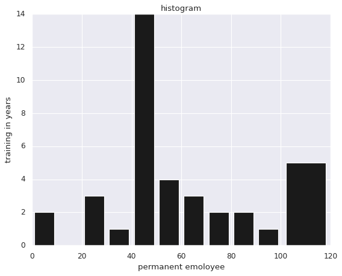

```python
plt.figure()
population_age=[22,55,62,45,21,22,34,42,42,4,2,102,95,85,55,110,120,70,65,55,111,115,80,75,65,54,44,43,42,48,40,40,40,41,42,45,49]
bins=[0,10,20,30,40,50,60,70,80,90,100,120]
plt.hist(population_age,bins,color="k",rwidth=0.8) #rwidth is the relative width
plt.xlabel("permanent emoloyee")
plt.ylabel("training in years")
plt.title("histogram")
plt.show()
```

```
 [Text(0, 0, '0'),
```

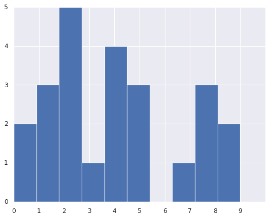

```python
plt.figure()
plt.hist([[1,2,3,4,5,2,4,7,8,4,5,2,1,8,8,0,9,0,9,2,5,2,1,4]])
plt.xticks(range(10))
```

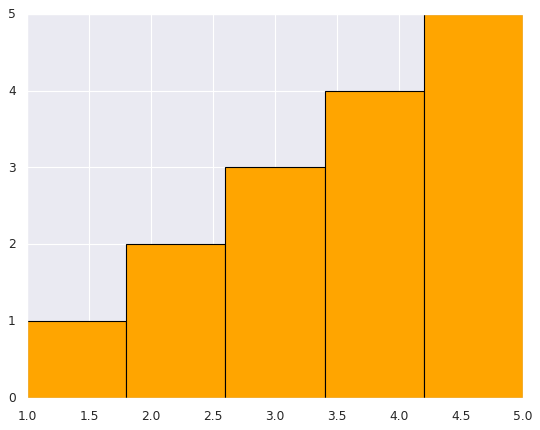

```python
data = [1, 2, 2, 3, 3, 3, 4, 4, 4, 4, 5, 5, 5, 5, 5]
plt.hist(data,bins=5,color='orange',edgecolor='black')
```

# Area Plotting

- Area plot is made by plotting a series of data points over time, connecting those data points with line segments and then filling in the area bt the line and the x axis with color or shading.
- Function - stackplot()

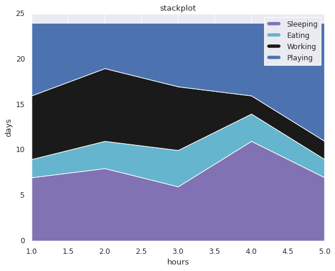

```python
plt.figure()
days = [1,2,3,4,5]
sleeping =[7,8,6,11,7]
eating = [2,3,4,3,2]
working =[7,8,7,2,2]
playing=[8,5,7,8,13]
plt.plot([],[],color='m', label='Sleeping', linewidth=5)
plt.plot([],[],color='c', label='Eating', linewidth=5)
plt.plot([],[],color='k', label='Working', linewidth=5)
plt.plot([],[],color='b', label='Playing', linewidth=5)
plt.stackplot(days,sleeping,eating,working,playing,colors=["m","c","k","b"])
plt.xlabel("hours")
plt.ylabel("days")
plt.title("stackplot")
plt.legend()
plt.show()
```

# Pie Chart

```
 [Text(0.764120788592483, 1.051722121304293, 'A'),
 [Text(0.47022817759537416, 0.6472136131103341, '30.0%'),
```

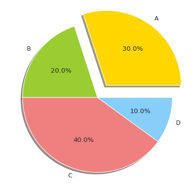

```python
labels=['A','B','C','D']
sizes=[30,20,40,10]
colors=['gold','yellowgreen','lightcoral','lightskyblue']
explode=(0.2,0,0,0) ##move out the 1st slice

##create apie chart
plt.pie(sizes,explode=explode,labels=labels,colors=colors,autopct="%1.1f%%",shadow=True)
```

```
 [Text(1.0461621663333946, 0.3399186987098808, ''),
  Text(-5.149471629032507e-08, 1.0999999999999988, ''),
  Text(-1.0999999999999954, -1.0298943258065002e-07, ''),
```

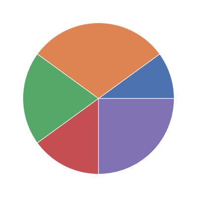

```python
plt.figure()
x=np.array([10,30,20,15,25])
plt.pie(x)
```

```
 [Text(0.8233618203614949, 0.7294349270298247, 'bananas'),
```

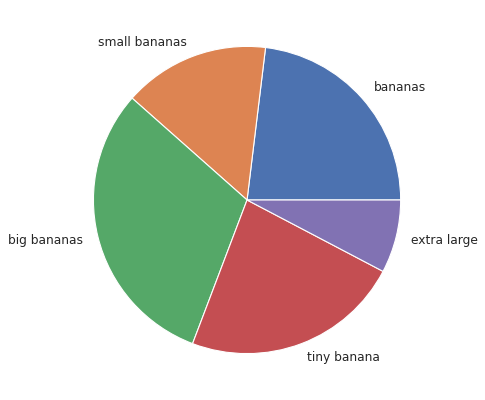

```python
y=np.array([30,20,40,30,10])
food=["bananas","small bananas","big bananas","tiny banana","extra large"]
plt.pie(y,labels=food)
```

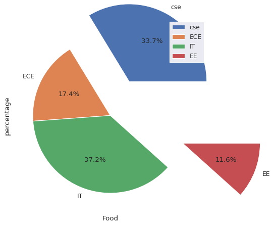

```python
branches=["cse","ECE","IT","EE"]
students_counts=[29,15,32,10]
exp=(0.5,0,0,1)
plt.pie(students_counts,labels=branches,explode=exp,autopct="%1.1f%%") #autopct help in determining the percentage of the branch.
plt.xlabel("Food")
plt.ylabel("percentage")
plt.legend()
plt.show()
```

# **Data Visulization using Seaborn**

# What is Python Seaborn?

- Seaborn is a library for making statistical graphics in Python.
- It is built on top of matplotlib and closely integrated with pandas data structures.

# Here is some of the functionality that seaborn offers:

Seaborn is a powerful Python library built on top of Matplotlib, specifically designed for statistical data visualization. Here are some of the key functionalities Seaborn offers:

1. Visualizing Distributions

distplot() (Deprecated) / histplot(): Visualizes the distribution of a single variable with options for histograms, kernel density estimation (KDE), or both. kdeplot(): Plots the kernel density estimate of a continuous variable. rugplot(): Adds small tick marks at each observation along the x-axis, providing a visual representation of data points.

1. Categorical Plots barplot(): Creates bar charts, showing mean values with confidence intervals. countplot(): Displays the count of observations in each categorical bin using bars. boxplot(): Draws box-and-whisker plots, useful for displaying distributions of data and detecting outliers. violinplot(): Combines aspects of boxplot and KDE to display both distribution shape and statistical summary. **stripplot() & swarmplot(): Show individual data points for categories, with swarmplot avoiding overlap.
2. Relational Plots scatterplot(): A simple scatter plot to visualize the relationship between two continuous variables. lineplot(): Visualizes the relationship between two variables, particularly useful for time series or sequential data. relplot(): A higher-level interface that can create scatter or line plots, allowing for easy faceting (splitting by additional categorical variables).
3. Matrix Plots heatmap(): Creates a color-coded matrix to visualize data, typically used for correlation matrices or displaying values across two dimensions. clustermap(): Generates a clustered heatmap with hierarchical clustering of rows and columns.
4. Pairwise Relationships pairplot(): Visualizes pairwise relationships between variables in a dataset by plotting scatter plots or KDE plots for all variable combinations. jointplot(): Combines a scatter plot with marginal histograms (or KDE) to show the relationship between two variables along with their distributions.
5. Regression Plots regplot(): Fits and visualizes a simple linear regression model between two variables. lmplot(): A higher-level interface for drawing regression plots with options for faceting by categorical variables. residplot(): Visualizes the residuals (errors) from a linear regression model.
6. Facet Grids FacetGrid(): Allows you to create multiple plots for subsets of data by mapping categorical variables to rows, columns, or color. catplot(): A simplified interface for drawing categorical plots on a FacetGrid.
7. Customizable Aesthetics Seaborn makes it easy to style plots with options like changing color palettes (sns.set_palette()), themes (sns.set_theme()), and adding grid lines.

```python
import numpy as np
import pandas as pd
import matplotlib.pyplot as plt
import seaborn as sns
%matplotlib inline
# enable inline plotting where graphs or plots will be displayed just below the cell
#you are writting the plotting commands
```

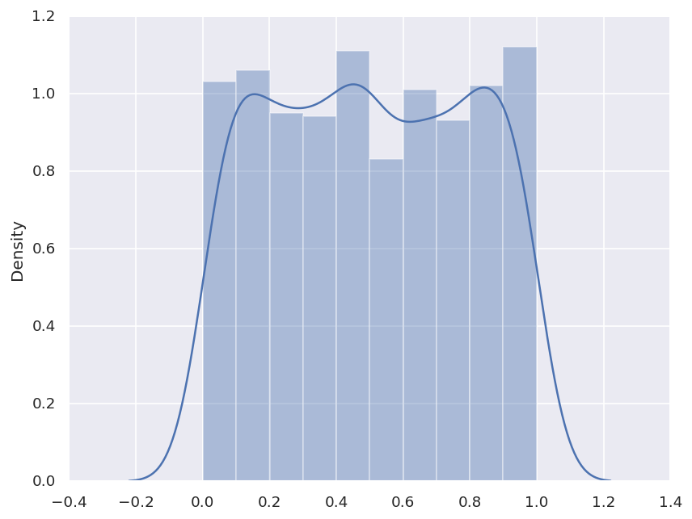

```python
x=np.random.random(1000)
plt.figure(dpi=120)
sns.distplot(x) #distributed plot (distribution plot)
```

```python
import matplotlib.pyplot as plt
plt.style.use("classic")
%matplotlib inline
```

```python
rng=np.random.RandomState(5)
x=np.linspace(0,10,500)
y=np.cumsum(rng.randn(500,6),0) #range of randn -1 to 1
```

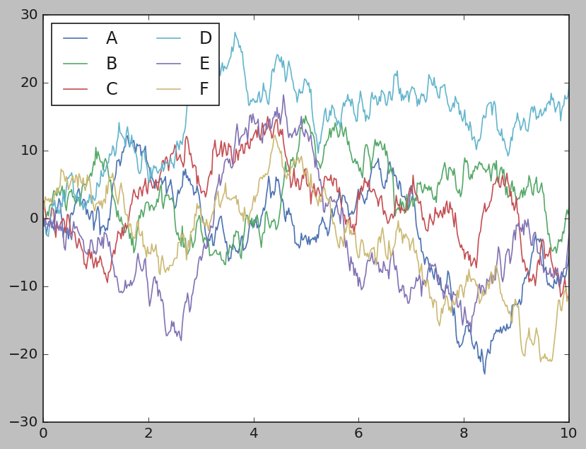

```python
plt.figure(dpi=120)
plt.plot(x,y)
plt.legend("ABCDEF",ncol=2,loc="upper left")
plt.show()
```

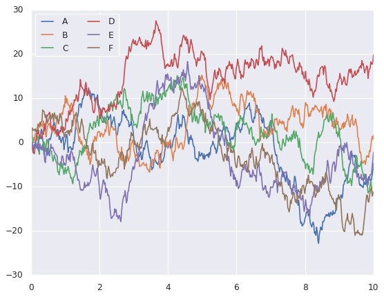

```python
sns.set()
plt.plot(x,y)
plt.legend("ABCDEF",ncol=2,loc="upper left")
plt.show()
```

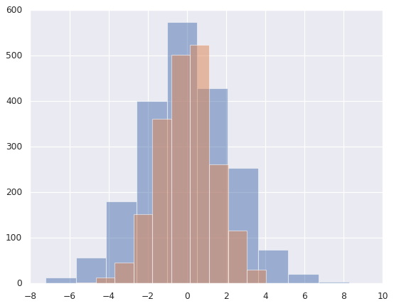

```python
#histogram, kde, densities

data=np.random.multivariate_normal([0,0],[[5,2],[2,2]],size=2000)
data1=pd.DataFrame(data,columns=["x","y"])

for item in "xy":
  plt.hist(data1[item],alpha=0.5)
```

```python
"""bar chart, box plot, line plot, bar horizontal - categorical plot
histo, kde, heatmap - distribution plot"""
```

```
'bar chart, box plot, line plot, bar horizontal - categorical plot\nhisto, kde, heatmap - distribution plot'
```

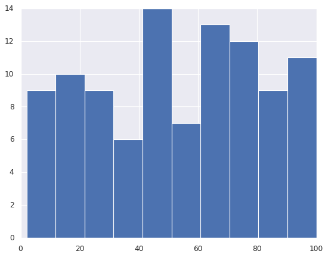

```python
marks=np.random.randint(1,101,100)
marks
plt.hist(x=marks)
plt.show()
```

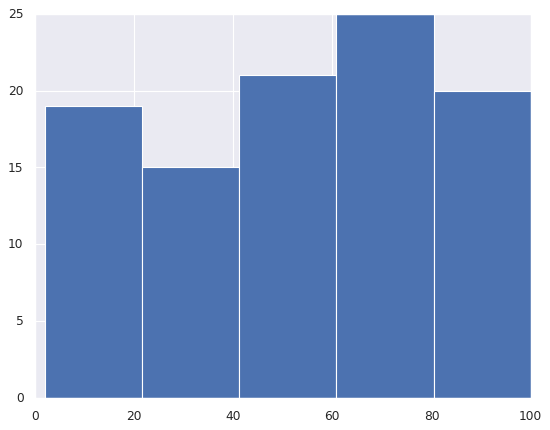

```python
plt.hist(x=marks,bins=5)
plt.show()
```

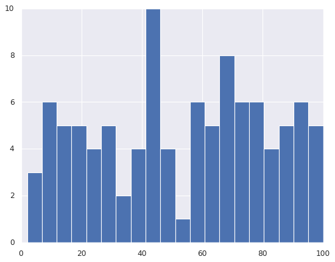

```python
plt.hist(x=marks,bins=20)
plt.show()
```

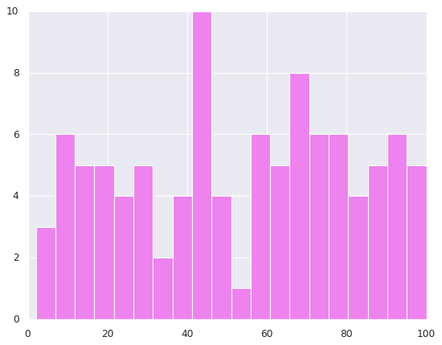

```python
plt.hist(x=marks,bins=20,histtype="bar",color="violet")
plt.show()
```

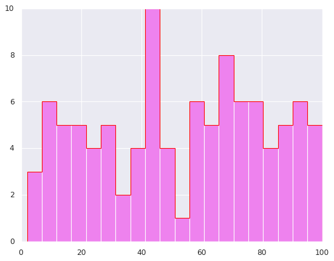

```python
plt.hist(x=marks,bins=20,histtype="bar",color="violet")
plt.hist(x=marks,bins=20,histtype="step",color="red")
plt.show()
```

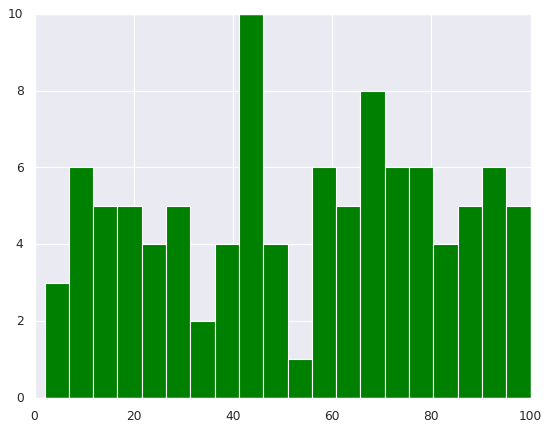

```python
plt.hist(x=marks,bins=20,histtype="bar",color="violet") #overclashing into each other
plt.hist(x=marks,bins=20,histtype="bar",color="green")
plt.show()
```

```python
import numpy as np
import pandas as pd
import matplotlib.pyplot as plt
import seaborn as sns
sns.set_theme(style="darkgrid")
```

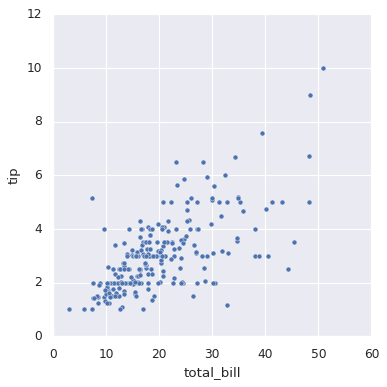

```python
tips = sns.load_dataset("tips")
sns.relplot(data=tips, x="total_bill", y="tip")
```

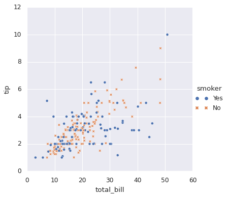

```python
sns.relplot(
    data=tips,
    x="total_bill", y="tip", hue="smoker", style="smoker"
)
```

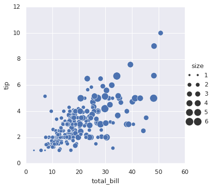

```python
sns.relplot(
    data=tips, x="total_bill", y="tip",
    size="size", sizes=(15, 200)
)
```

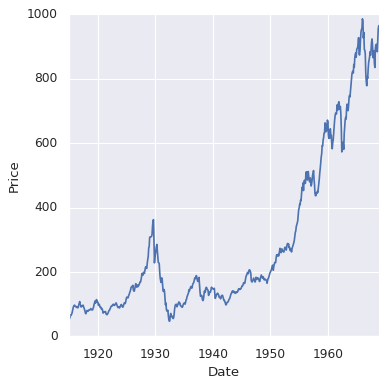

```python
dowjones = sns.load_dataset("dowjones")
sns.relplot(data=dowjones, x="Date", y="Price", kind="line")
```

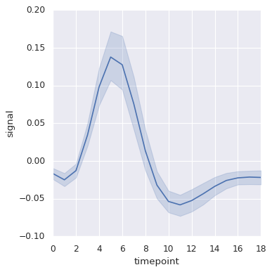

```python
fmri = sns.load_dataset("fmri")
sns.relplot(data=fmri, x="timepoint", y="signal", kind="line")
```

## Some other Plots

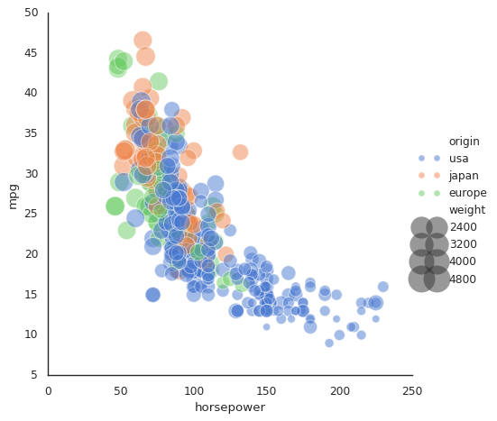

```python
#1.replot()
import seaborn as sns
sns.set(style="white")

# Load the example mpg dataset
mpg = sns.load_dataset("mpg")

# Plot miles per gallon against horsepower with other semantics
sns.relplot(x="horsepower", y="mpg", hue="origin", size="weight",
            sizes=(400, 40), alpha=.5, palette="muted",
            height=6, data=mpg)
```

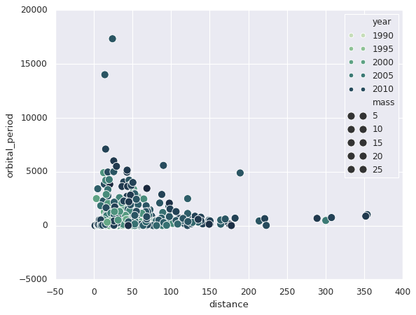

```python
#2. seaborn.scatterplot()

#Draws a scatter plot with the possibility of several semantic groupings.
import seaborn as sns
sns.set()

# Load the example iris dataset
planets = sns.load_dataset("planets")

cmap = sns.cubehelix_palette(rot=-.5, as_cmap=True)
ax = sns.scatterplot(x="distance", y="orbital_period",
                     hue="year", size="mass",
                     palette=cmap, sizes=(100, 100),
                     data=planets)
```

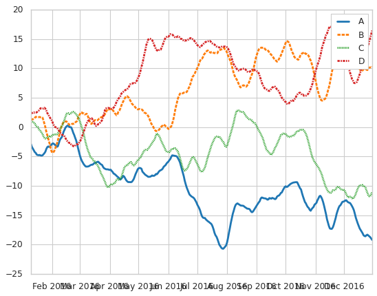

```python
#3. seaborn.lineplot()

sns.set(style="whitegrid")

rs = np.random.RandomState(365)
values = rs.randn(365, 4).cumsum(axis=0)
dates = pd.date_range("1 1 2016", periods=365, freq="D")
data = pd.DataFrame(values, dates, columns=["A", "B", "C", "D"])
data = data.rolling(10).mean()

sns.lineplot(data=data, palette="tab10", linewidth=2.5)
```

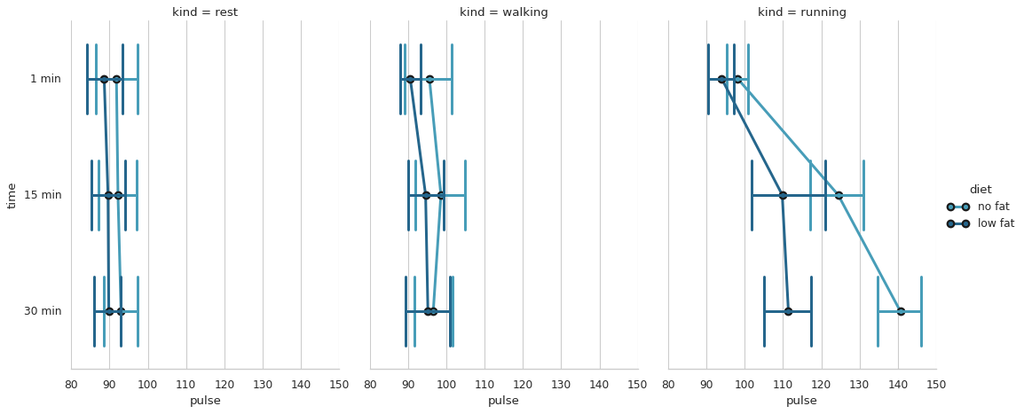

```python
#4. seaborn.catplot()
import seaborn as sns
sns.set(style="whitegrid")

# Load the example exercise dataset
df = sns.load_dataset("exercise")

# Draw a pointplot to show pulse as a function of three categorical factors
g = sns.catplot(x="pulse", y="time", hue="diet", col="kind",
                capsize=.6, palette="YlGnBu_d", height=6, aspect=.75,
                kind="point", data=df)
g.despine(left=True)
```

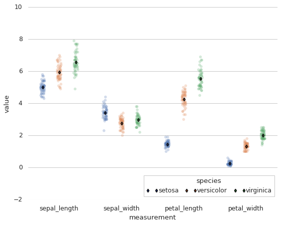

```python
#5. seaborn.stripplot()
import pandas as pd
import seaborn as sns
import matplotlib.pyplot as plt

sns.set(style="whitegrid")
iris = sns.load_dataset("iris")

# "Melt" the dataset to "long-form" or "tidy" representation
iris = pd.melt(iris, "species", var_name="measurement")

# Initialize the figure
f, ax = plt.subplots()
sns.despine(bottom=True, left=True)

# Show each observation with a scatterplot
sns.stripplot(x="measurement", y="value", hue="species",
              data=iris, dodge=True, jitter=True,
              alpha=.25, zorder=1)

# Show the conditional means
sns.pointplot(x="measurement", y="value", hue="species",
              data=iris, dodge=.532, join=False, palette="dark",
              markers="d", scale=.75, ci=None)

# Improve the legend
handles, labels = ax.get_legend_handles_labels()
ax.legend(handles[3:], labels[3:], title="species",
          handletextpad=0, columnspacing=1,
          loc="lower right", ncol=3, frameon=True)
```

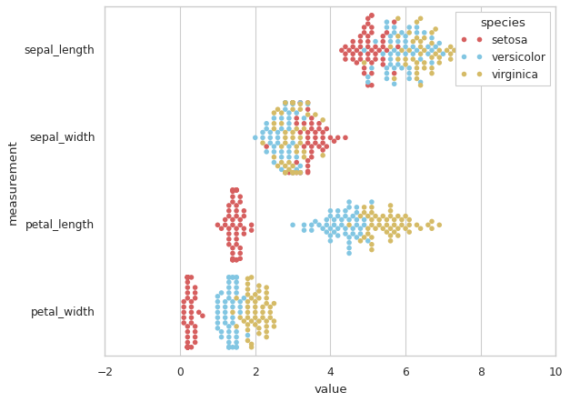

```python
#6. seaborn.swarmplot()
import pandas as pd
import seaborn as sns
sns.set(style="whitegrid", palette="muted")

# Load the example iris dataset
iris = sns.load_dataset("iris")

# "Melt" the dataset to "long-form" or "tidy" representation
iris = pd.melt(iris, "species", var_name="measurement")

# Draw a categorical scatterplot to show each observation
sns.swarmplot(x="value", y="measurement", hue="species",
              palette=["r", "c", "y"], data=iris)
```

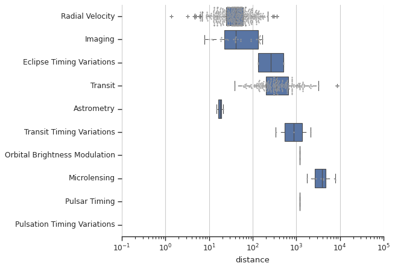

```python
#7.seaborn.boxplot()
import seaborn as sns
import matplotlib.pyplot as plt

sns.set(style="ticks")

# Initialize the figure with a logarithmic x axis
f, ax = plt.subplots(figsize=(7, 6))
ax.set_xscale("log")

# Load the example planets dataset
planets = sns.load_dataset("planets")

# Plot the orbital period with horizontal boxes
sns.boxplot(x="distance", y="method", data=planets)

# Add in points to show each observation
sns.swarmplot(x="distance", y="method", data=planets, size=2, color=".6", linewidth=0)

# Tweak the visual presentation
ax.xaxis.grid(True)
ax.set(ylabel="")
sns.despine(trim=True, left=True)
```

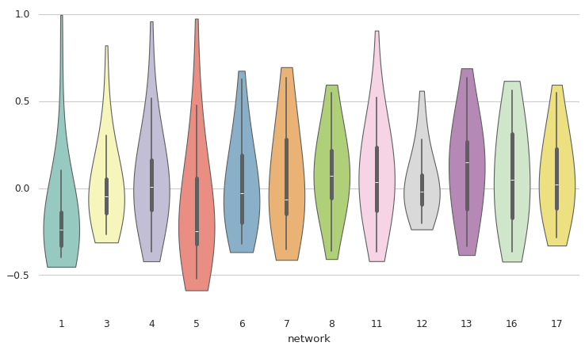

```python
#8. seaborn.violinplot()
import seaborn as sns
import matplotlib.pyplot as plt
sns.set(style="whitegrid")

# Load the example dataset of brain network correlations
df = sns.load_dataset("brain_networks", header=[0, 1, 2], index_col=0)

# Pull out a specific subset of networks
used_networks = [1, 3, 4, 5, 6, 7, 8, 11, 12, 13, 16, 17]
used_columns = (df.columns.get_level_values("network")
                          .astype(float)
                          .isin(used_networks))
df = df.loc[:, used_columns]

# Compute the correlation matrix and average over networks
corr_df = df.corr().groupby(level="network").mean()
corr_df.index = corr_df.index.astype(int)
corr_df = corr_df.sort_index().T

# Set up the matplotlib figure
f, ax = plt.subplots(figsize=(11, 6))

# Draw a violinplot with a narrower bandwidth than the default
sns.violinplot(data=corr_df, palette="Set3", bw=1, cut=.2, linewidth=1)

# Finalize the figure
ax.set(ylim=(-.7, 1.05))
sns.despine(left=True, bottom=True)
```

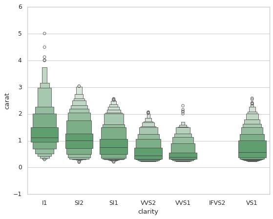

```python
#9. seaborn.boxenplot()
import seaborn as sns
sns.set(style="whitegrid")

diamonds = sns.load_dataset("diamonds")
clarity_ranking = ["I1", "SI2", "SI1", "VVS2", "VVS1", "IF" "VS2", "VS1"]

sns.boxenplot(x="clarity", y="carat",
              color="g", order=clarity_ranking,
              scale="linear", data=diamonds)
```

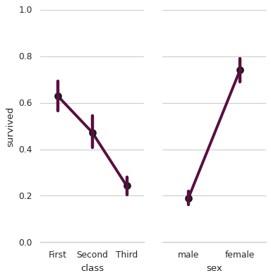

```python
#10. seaborn.pointplot()
import seaborn as sns
sns.set(style="whitegrid")

# Load the example Titanic dataset
titanic = sns.load_dataset("titanic")

# Set up a grid to plot survival probability against several variables
g = sns.PairGrid(titanic, y_vars="survived",
                 x_vars=["class", "sex"],
                 height=5, aspect=.5)

# Draw a seaborn pointplot onto each Axes
g.map(sns.pointplot, scale=1.3, errwidth=4, color="xkcd:plum")
g.set(ylim=(0, 1))
sns.despine(fig=g.fig, left=True)
```

[output not shown]

[output cut: 20 more lines]

[output not shown]

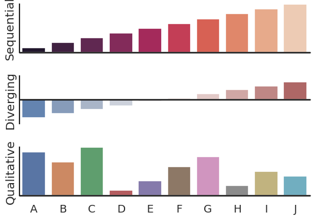

```python
#11. seaborn.barplot()
import numpy as np
import seaborn as sns
import matplotlib.pyplot as plt
sns.set(style="white", context="talk")
rs = np.random.RandomState(8)

# Set up the matplotlib figure
f, (ax1, ax2, ax3) = plt.subplots(3, 1, figsize=(7, 5), sharex=True)

# Generate some sequential data
x = np.array(list("ABCDEFGHIJ"))
y1 = np.arange(1, 11)
sns.barplot(x=x, y=y1, palette="rocket", ax=ax1)
ax1.axhline(0, color="k", clip_on=False)
ax1.set_ylabel("Sequential")

# Center the data to make it diverging
y2 = y1 - 5.5
sns.barplot(x=x, y=y2, palette="vlag", ax=ax2)
ax2.axhline(0, color="k", clip_on=False)
ax2.set_ylabel("Diverging")

# Randomly reorder the data to make it qualitative
y3 = rs.choice(y1, len(y1), replace=False)
sns.barplot(x=x, y=y3, palette="deep", ax=ax3)
ax3.axhline(0, color="k", clip_on=False)
ax3.set_ylabel("Qualitative")

# Finalize the plot
sns.despine(bottom=True)
plt.setp(f.axes, yticks=[])
plt.tight_layout(h_pad=2)
```

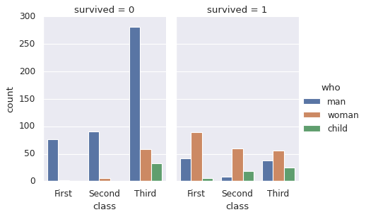

```python
#12. seaborn.countplot
import seaborn as sns
sns.set(style="darkgrid")
titanic = sns.load_dataset("titanic")
g = sns.catplot(x="class", hue="who", col="survived", data=titanic, kind="count", height=4, aspect=.7)
```

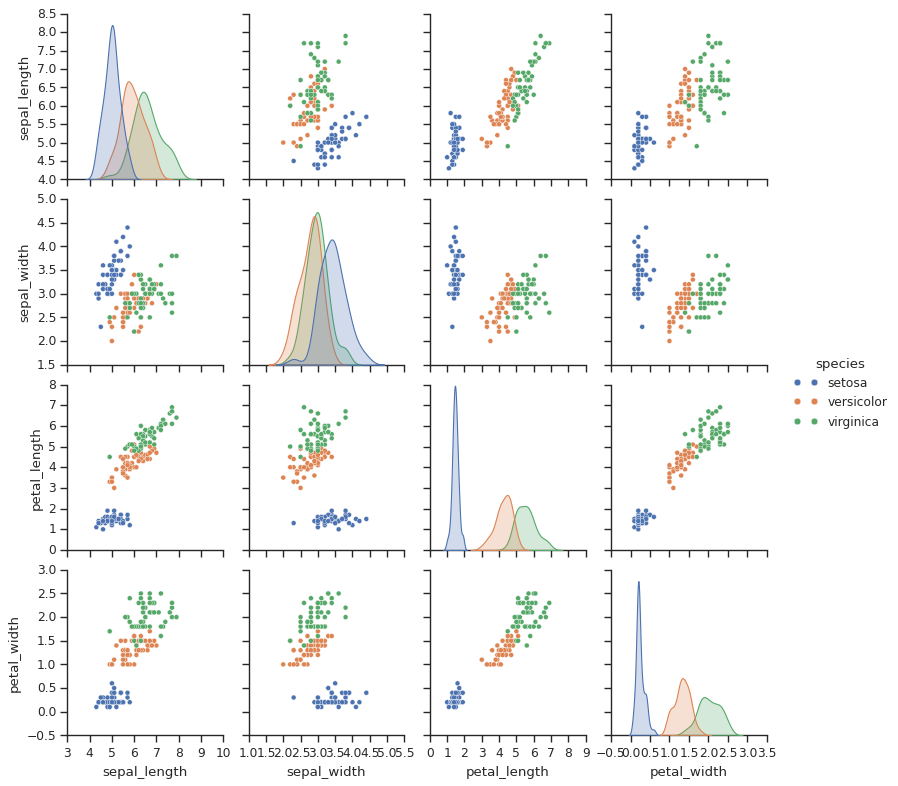

```python
#13. seaborn.pairplot()
import seaborn as sns
sns.set(style="ticks")

df = sns.load_dataset("iris")
sns.pairplot(df, hue="species")
```

[output not shown]

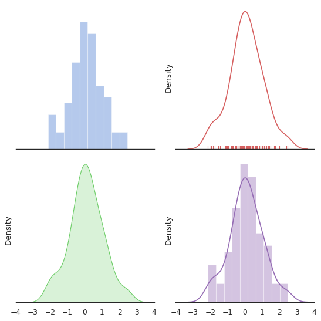

```python
#14. seaborn.distplot()

sns.set(style="white", palette="muted", color_codes=True)
rs = np.random.RandomState(10)

# Set up the matplotlib figure
f, axes = plt.subplots(2, 2, figsize=(7, 7), sharex=True)
sns.despine(left=True)

# Generate a random univariate dataset
d = rs.normal(size=100)

# Plot a simple histogram with binsize determined automatically
sns.distplot(d, kde=False, color="b", ax=axes[0, 0])

# Plot a kernel density estimate and rug plot
sns.distplot(d, hist=False, rug=True, color="r", ax=axes[0, 1])

# Plot a filled kernel density estimate
sns.distplot(d, hist=False, color="g", kde_kws={"shade": True}, ax=axes[1, 0])

# Plot a historgram and kernel density estimate
sns.distplot(d, color="m", ax=axes[1, 1])

plt.setp(axes, yticks=[])
plt.tight_layout()
```

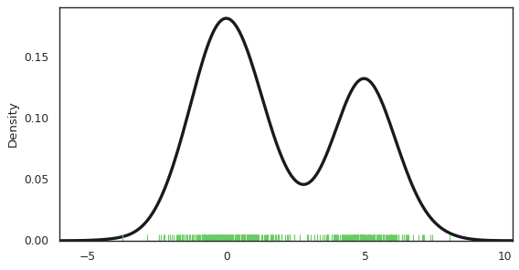

```python
#15 seaborn.rugplot()
import numpy as np
import matplotlib.pyplot as plt
import seaborn as sns
sample = np.hstack((np.random.randn(300), np.random.randn(200)+5))
fig, ax = plt.subplots(figsize=(8,4))
sns.distplot(sample, rug=True, hist=False, rug_kws={"color": "g"},
    kde_kws={"color": "k", "lw": 3})
plt.show()
```

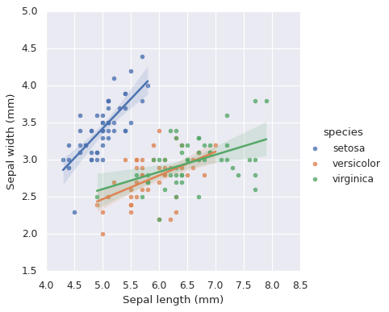

```python
#16. seaborn.lmplot()
import seaborn as sns
sns.set()

# Load the iris dataset
iris = sns.load_dataset("iris")

# Plot sepal with as a function of sepal_length across days
g = sns.lmplot(x="sepal_length", y="sepal_width", hue="species",
               truncate=True, height=5, data=iris)

# Use more informative axis labels than are provided by default
g.set_axis_labels("Sepal length (mm)", "Sepal width (mm)")
```

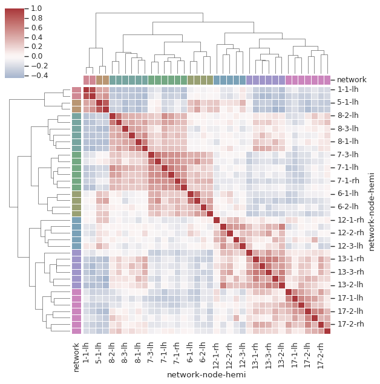

```python
#17 seaborn.clustermap()

# Load the brain networks example dataset
df = sns.load_dataset("brain_networks", header=[0, 1, 2], index_col=0)

# Select a subset of the networks
used_networks = [1, 5, 6, 7, 8, 12, 13, 17]
used_columns = (df.columns.get_level_values("network")
                          .astype(int)
                          .isin(used_networks))
df = df.loc[:, used_columns]

# Create a categorical palette to identify the networks
network_pal = sns.husl_palette(8, s=.45)
network_lut = dict(zip(map(str, used_networks), network_pal))

# Convert the palette to vectors that will be drawn on the side of the matrix
networks = df.columns.get_level_values("network")
network_colors = pd.Series(networks, index=df.columns).map(network_lut)

# Draw the full plot
sns.clustermap(df.corr(), center=0, cmap="vlag",
               row_colors=network_colors, col_colors=network_colors,
               linewidths=.75, figsize=(8, 8))
```

```python
# Consider Tips dataset from seaborn

tips=sns.load_dataset('tips')
tips
```

|  | total_bill | tip | sex | smoker | day | time | size |
| --- | --- | --- | --- | --- | --- | --- | --- |
| 0 | 16.99 | 1.01 | Female | No | Sun | Dinner | 2 |
| 1 | 10.34 | 1.66 | Male | No | Sun | Dinner | 3 |
| 2 | 21.01 | 3.50 | Male | No | Sun | Dinner | 3 |
| 3 | 23.68 | 3.31 | Male | No | Sun | Dinner | 2 |
| 4 | 24.59 | 3.61 | Female | No | Sun | Dinner | 4 |
| ... | ... | ... | ... | ... | ... | ... | ... |
| 239 | 29.03 | 5.92 | Male | No | Sat | Dinner | 3 |
| 240 | 27.18 | 2.00 | Female | Yes | Sat | Dinner | 2 |
| 241 | 22.67 | 2.00 | Male | Yes | Sat | Dinner | 2 |
| 242 | 17.82 | 1.75 | Male | No | Sat | Dinner | 2 |
| 243 | 18.78 | 3.00 | Female | No | Thur | Dinner | 2 |

244 rows × 7 columns

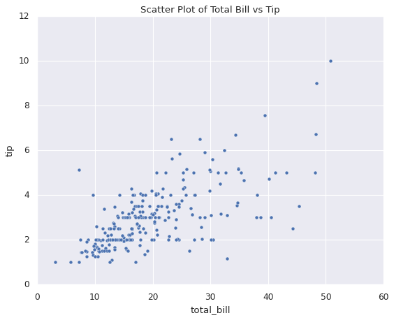

```python
sns.scatterplot(x='total_bill',y='tip',data=tips)
plt.title("Scatter Plot of Total Bill vs Tip")
plt.show()
```

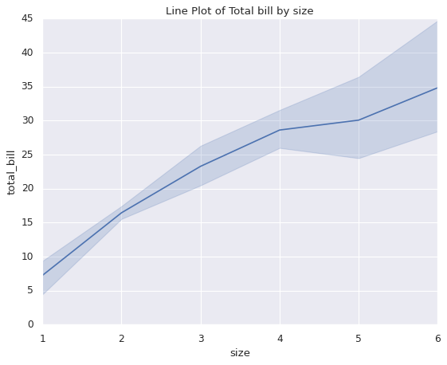

```python
## Line Plot

sns.lineplot(x='size',y='total_bill',data=tips)
plt.title("Line Plot of Total bill by size")
plt.show()
```

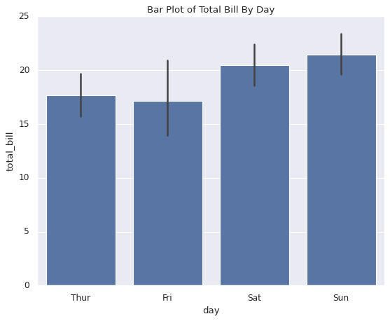

```python
## Categorical Plots
## BAr Plot
sns.barplot(x='day',y='total_bill',data=tips)
plt.title('Bar Plot of Total Bill By Day')
plt.show()
```

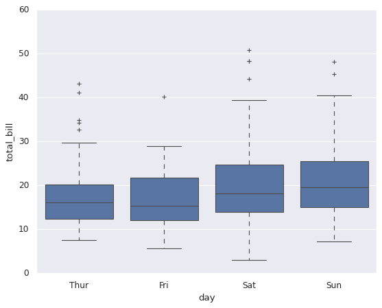

```python
## Box Plot
sns.boxplot(x="day",y='total_bill',data=tips)
```

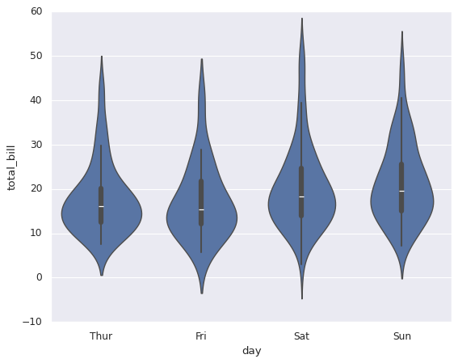

```python
## Violin Plot

sns.violinplot(x='day',y='total_bill',data=tips)
```

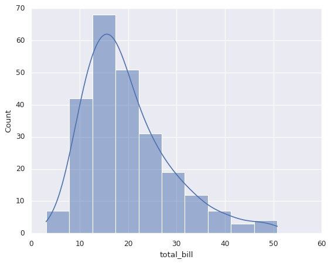

```python
### Histograms
sns.histplot(tips['total_bill'],bins=10,kde=True)
```

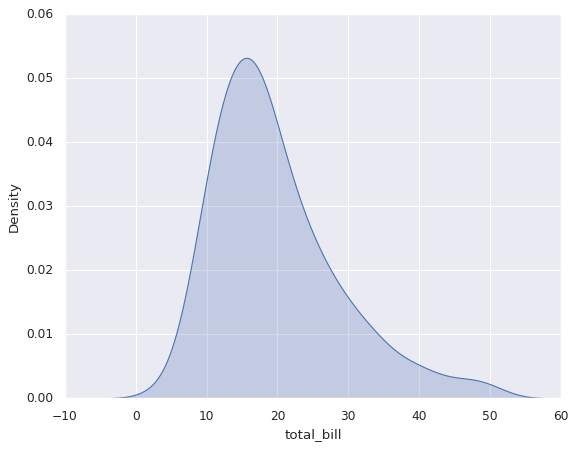

```python
## KDE Plot
sns.kdeplot(tips['total_bill'],fill=True)
```

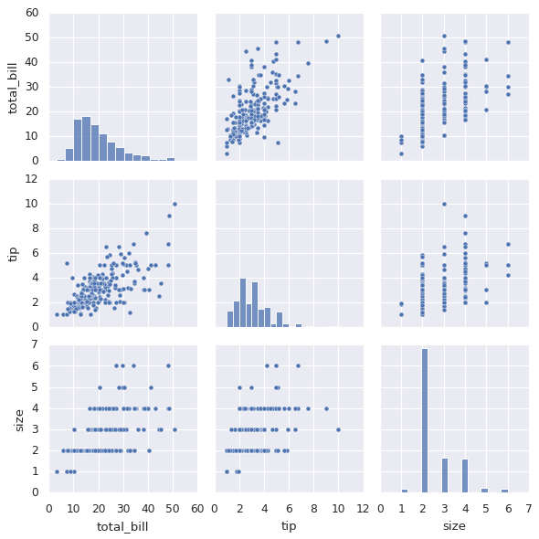

```python
# Pairplot
sns.pairplot(tips)
```

```python
## HEatmap
corr=tips[['total_bill','tip','size']].corr()
corr
```

|  | total_bill | tip | size |
| --- | --- | --- | --- |
| total_bill | 1.000000 | 0.675734 | 0.598315 |
| tip | 0.675734 | 1.000000 | 0.489299 |
| size | 0.598315 | 0.489299 | 1.000000 |

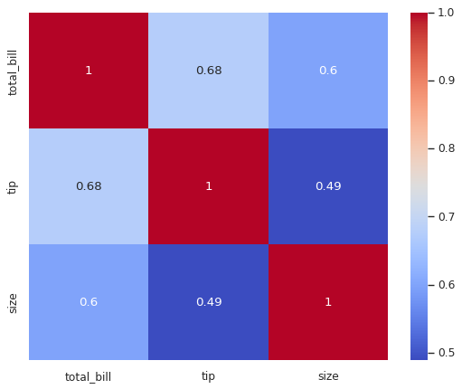

```python
sns.heatmap(corr,annot=True,cmap='coolwarm')
```